# Introduction Workearly Final Assignment Python Data

- Author: Panagiotis Chatzinikolaou
- e-mail: chatzinp@gmail.com

Tasks:

- For the timeframe 2016-2019:
  1. Discern the most popular item in each zipcode
  2. Compute the sales percentage per store (in dollars)

Objectives:

- *Data Extraction and Cleaning*: Extract pertinent data and conduct preliminary cleaning to handle missing or inconsistent data.
- *Data Analysis*: Employ Python with Pandas or SQL to analyze the dataset, identifying the predominant item per zipcode and calculating the proportion of sales for each store between 2016 and 2019.
- *Data Visualization*: Represent the analyzed data aesthetically and informatively using tools like matplotlib, seaborn, plotly, or integrate with visualization platforms such as Tableau Public, Power BI, Looker Studio, or HEX for a more interactive experience.

PS. You will only need 1 type of graph for the solution, but feel free to experiment with different graphs and formats.

Constraints:

- All data computations, transformations, and manipulations must be executed via Python scripts.
- The visual representation should succinctly convey the findings, maintaining a balance between detail and clarity.

Deliverables:

- **Analytical Report**: A comprehensive report detailing the methodologies used, the analysis performed, and the insights derived as well as the code.
- **Visualization Dashboard**: An interactive dashboard or a set of plots/graphs using one of the prescribed tools, encapsulating the key findings and insights.

Workflow:

- *Data Preparation*: Extract, clean, and prepare the dataset for analysis.
- *Exploratory Data Analysis (EDA)*: Explore the dataset to understand its structure, trends, and patterns.
- *Data Manipulation*: Use Python and Pandas for data transformation and computation to derive insights.
- *Visualization and Presentation*: Present the results in a visually appealing and informative manner using suitable visualization tools.

## Libraries

For this assignment I used pandas for data manipulation, as well as matplotlib, seaborn and plotly for data visualization. All code was created in VS Code in a Jupyter notebook (ipynb).

```python
# Install required packages for the project
pip install pandas
pip install matplotlib
pip install seaborn
pip install plotly
```

```python
# Import required packages
import pandas as pd
import numpy as np
import matplotlib.pyplot as plt
import seaborn as sns
import plotly.express as px
```

## Data Preparation

In this section, I followed the next steps to prepare the dataset:

- Extract the data from the csv file using pandas and read it to a Pandas DataFrame.
- Check for any missing data and drop them.
- Check the data types of the dataset and make any necessary conversions.

```python
# Extract the data from the CSV file
df = pd.read_csv('https://storage.googleapis.com/courses_data/Assignment%20CSV/finance_liquor_sales.csv')
```

```python
# Check for missing data
print("Missing Data:\n", df.isna().sum())
```

```
Missing Data:
 invoice_and_item_number     0
date                        0
store_number                0
store_name                  0
address                     0
city                        0
zip_code                    0
store_location             18
county_number               1
county                      1
category                    3
category_name               9
vendor_number               0
vendor_name                 0
item_number                 0
item_description            0
pack                        0
bottle_volume_ml            0
state_bottle_cost           0
state_bottle_retail         0
bottles_sold                0
sale_dollars                0
volume_sold_liters          0
volume_sold_gallons         0
dtype: int64
```

```python
# Find the item_number of the missing store_location
#df['item_number'].isna()
store_location_na = df[df['store_location'].isna()]["item_number"]

# Find the item number of the missing county number
county_numb_na = df[df['county_number'].isna()]["item_number"]

# Find the item number of the missing category name
cat_name_na = df[df['category_name'].isna()]["item_number"]

# Find the item number of the missing category
category_na = df[df['category'].isna()]["item_number"]

# Find the item number of the missing county
county_na = df[df['county'].isna()]["item_number"]

# Print the item number for each missing data
print("Item Number for missing store location: ", store_location_na)
print("")
print("Item Number for missing county number: ", county_numb_na)
print("")
print("Item Number for missing category name: ", cat_name_na)
print("")
print("Item Number for missing category: ", category_na)
print("")
print("Item Number for missing county: ", county_na)
```

```
Item Number for missing store location:  2       41844
39      49182
55      78115
56      15644
59      84617
80      56193
82      36908
94      77487
103     43031
119     82187
128     43034
147    101181
151     76436
171     28868
174     77805
175     67524
183     86112
199     33717
Name: item_number, dtype: int64

Item Number for missing county number:  66    905153
Name: item_number, dtype: int64

Item Number for missing category name:  21     100026
37      48106
38      48099
39      49182
61      48099
69      84197
102     84197
153     48099
181     48099
Name: item_number, dtype: int64

Item Number for missing category:  21     100026
69      84197
102     84197
Name: item_number, dtype: int64

Item Number for missing county:  66    905153
Name: item_number, dtype: int64
```

```python
# Check the data types of the columns
df.dtypes
df.info()
```

[output not shown]

[output cut: 16 more lines]

```python
# Convert the date column to datetime
df['date'] = pd.to_datetime(df['date'])
```

## Exploratory Data Analysis

In this section, I used some basic functions to further explore the liquor sales dataset.

```python
# Column names
df.columns
```

```
Index(['invoice_and_item_number', 'date', 'store_number', 'store_name',
       'address', 'city', 'zip_code', 'store_location', 'county_number',
       'county', 'category', 'category_name', 'vendor_number', 'vendor_name',
       'item_number', 'item_description', 'pack', 'bottle_volume_ml',
       'state_bottle_cost', 'state_bottle_retail', 'bottles_sold',
       'sale_dollars', 'volume_sold_liters', 'volume_sold_gallons'],
      dtype='object')
```

```python
# View the first few rows of the data
df.head()
```

|  | invoice_and_item_number | date | store_number | store_name | address | city | zip_code | store_location | county_number | county | ... | item_number | item_description | pack | bottle_volume_ml | state_bottle_cost | state_bottle_retail | bottles_sold | sale_dollars | volume_sold_liters | volume_sold_gallons |
| --- | --- | --- | --- | --- | --- | --- | --- | --- | --- | --- | --- | --- | --- | --- | --- | --- | --- | --- | --- | --- | --- |
| 0 | INV-31797900035 | 2020-11-10 | 4967 | Jeff's Market / Blue Grass | 102, W Mayne St | Blue Grass | 52726.0 | POINT (-90.766126 41.509119) | 82.0 | SCOTT | ... | 26858 | Templeton 4YR Rye | 12 | 375 | 9.99 | 14.99 | 1 | 14.99 | 0.37 | 0.09 |
| 1 | INV-23548800092 | 2019-11-27 | 2601 | Hy-Vee Food Store / Fairfield | 1300 West Burlington Ave | Fairfield | 52556.0 | POINT (-91.978702 41.006456) | 51.0 | JEFFERSON | ... | 86251 | Juarez Triple Sec | 12 | 1000 | 2.42 | 3.63 | 6 | 21.78 | 6.00 | 1.58 |
| 3 | INV-39482900037 | 2021-08-24 | 3719 | Wal-Mart 0581 / Marshalltown | 2802 S Center St | Marshalltown | 50158.0 | POINT (-92.91231 42.012918) | 64.0 | MARSHALL | ... | 65259 | Jagermeister Liqueur Mini Meisters | 12 | 20 | 4.93 | 7.40 | 12 | 88.80 | 0.24 | 0.06 |
| 4 | INV-39520400088 | 2021-08-25 | 5423 | Stammer Liquor Corp | 615 2nd Ave | Sheldon | 51201.0 | POINT (-95.854899 43.184242) | 71.0 | OBRIEN | ... | 77487 | Tortilla Gold DSS | 12 | 1000 | 4.85 | 7.28 | 4 | 29.12 | 4.00 | 1.05 |
| 5 | INV-29941700050 | 2020-09-02 | 3842 | Bancroft Liquor Store | 107 N Portland St Po Bx 222 | Bancroft | 50517.0 | POINT (-94.218 43.29355) | 55.0 | KOSSUTH | ... | 77055 | Sir Winston Peach | 6 | 750 | 13.01 | 19.52 | 18 | 351.36 | 13.50 | 3.56 |

5 rows × 24 columns

```python
# Calculate basic statistics
df.describe()
```

|  | date | store_number | zip_code | county_number | category | vendor_number | item_number | pack | bottle_volume_ml | state_bottle_cost | state_bottle_retail | bottles_sold | sale_dollars | volume_sold_liters | volume_sold_gallons |
| --- | --- | --- | --- | --- | --- | --- | --- | --- | --- | --- | --- | --- | --- | --- | --- |
| count | 173 | 173.000000 | 173.000000 | 173.000000 | 1.730000e+02 | 173.000000 | 173.000000 | 173.000000 | 173.000000 | 173.000000 | 173.000000 | 173.000000 | 173.000000 | 173.000000 | 173.000000 |
| mean | 2017-08-23 18:35:22.543352576 | 3647.624277 | 51406.271676 | 56.161850 | 1.174537e+06 | 277.421965 | 100839.456647 | 10.982659 | 879.739884 | 10.363757 | 15.549827 | 59.716763 | 778.680116 | 57.004971 | 15.057283 |
| min | 2012-01-17 00:00:00 | 2178.000000 | 50009.000000 | 3.000000 | 1.011300e+06 | 35.000000 | 168.000000 | 3.000000 | 20.000000 | 0.890000 | 1.340000 | 1.000000 | 6.750000 | 0.150000 | 0.030000 |
| 25% | 2014-12-18 00:00:00 | 2593.000000 | 50401.000000 | 43.000000 | 1.051110e+06 | 85.000000 | 28868.000000 | 6.000000 | 750.000000 | 4.750000 | 7.130000 | 4.000000 | 50.820000 | 4.000000 | 1.060000 |
| 50% | 2017-06-28 00:00:00 | 3447.000000 | 51401.000000 | 57.000000 | 1.081330e+06 | 300.000000 | 67522.000000 | 12.000000 | 1000.000000 | 8.390000 | 12.590000 | 24.000000 | 217.800000 | 13.500000 | 3.560000 |
| 75% | 2020-09-16 00:00:00 | 4319.000000 | 52317.000000 | 77.000000 | 1.091300e+06 | 421.000000 | 82847.000000 | 12.000000 | 1000.000000 | 15.000000 | 22.500000 | 72.000000 | 813.900000 | 60.000000 | 15.850000 |
| max | 2022-06-28 00:00:00 | 9001.000000 | 52807.000000 | 97.000000 | 1.901200e+06 | 662.000000 | 986845.000000 | 48.000000 | 1750.000000 | 34.990000 | 52.490000 | 900.000000 | 7240.860000 | 900.000000 | 237.750000 |
| std | NaN | 1237.073414 | 944.644489 | 26.700913 | 2.556170e+05 | 153.748439 | 200713.107601 | 6.697339 | 426.273832 | 7.068157 | 10.603641 | 115.172901 | 1281.964148 | 119.504567 | 31.569571 |

*Note: We notice that the earlieast year of the dataset is 2012 and the latest is 2022. For this assignment, we need only the dates between 2016-2019. So we will filter the dataset for the given timeframe.*

```python
# Filter the data to only include the data between 2016 and 2019
# Using base Python
#df_clean = df[(df['date'] >= '2016-01-01') & (df['date'] <= '2019-12-31')]

# Using pandas query
df_clean = df.query('date >= "2016-01-01" and date <= "2019-12-31"')
```

```python
# Print the earliest and latest date in the filtered data
print("Earliest date is: \n", df_clean["date"].min())
print("")
print("Latest date is: \n", df_clean["date"].max())
```

```
Earliest date is:
 2016-01-13 00:00:00

Latest date is:
 2019-12-31 00:00:00
```

## Task 1

The aim of this task is to identify the most popular item per zip code. Thus, we first need to find which item was sold the most in each zipcode.

### Data manipulation

```python
# Group by zip_code and item_description, then sum the bottles_sold
most_popular = df_clean.groupby(['zip_code', 'item_number'])['bottles_sold'].sum().reset_index()

# Display the top ten most popular items
print(most_popular.head(10))
```

```
   zip_code  item_number  bottles_sold
0   50010.0       946574           288
1   50022.0        86507             4
2   50111.0        77805           108
3   50131.0        38089            48
4   50158.0        48099            24
5   50158.0        67528             3
6   50158.0        67557             6
7   50263.0         3135            84
8   50265.0        67526            72
9   50266.0          250            90
```

```python
# sort the data by bottles_sold in descending order
most_popular_sorted = most_popular.sort_values(by='bottles_sold', ascending=False)

# Display the top ten most popular items
print(most_popular_sorted.head(10))
```

```
    zip_code  item_number  bottles_sold
62   52314.0        75087          1560
30   50702.0        77487           768
0    50010.0       946574           288
39   51106.0        67527           240
13   50314.0        86251           240
65   52402.0        86390           216
33   50703.0          168           180
41   51106.0        86251           144
19   50320.0       973627           120
2    50111.0        77805           108
```

### Plotting

First, we are going to use matplotlib to create a scatterplot of bottles sold and zipcode.

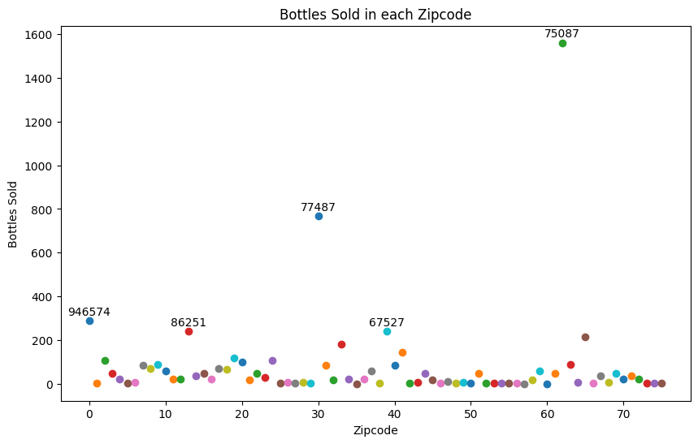

```python
# Set up the figure
plt.figure(figsize=(10, 6))

# Loop through each row and plot each data point using the index as the x-axis
for index, row in most_popular.iterrows():
    plt.scatter(index, row['bottles_sold'], label=f"Item {row['item_number']}")

    # Annotate item_number if bottles_sold > 250, no decimals
    if row['bottles_sold'] > 220:
        plt.annotate(
            f'{int(row["item_number"])}',  # Convert item_number to integer to remove decimals
            (index, row['bottles_sold']),
            textcoords="offset points",
            xytext=(0, 5),
            ha="center"
        )

# Add labels and title
plt.xlabel('Zipcode')
plt.ylabel('Bottles Sold')
plt.title('Bottles Sold in each Zipcode')

# Show the plot
plt.show()
```

Just for fun, we are going to replicate the plot using seaborn.

[figure not shown]

```python
# Set up the plot

# Create scatter plot using seaborn with all points in blue and no legend
sns.scatterplot(
    x=most_popular.index,
    y='bottles_sold',
    data=most_popular,
    color='blue',   # Color all points blue
    s=50            # Increase size of points to 50
)

# Annotate points where bottles_sold > 220, no decimals
for i, row in most_popular[most_popular['bottles_sold'] > 250].iterrows():
    plt.annotate(
        f'{int(row["item_number"])}',  # Convert item_number to integer to remove decimals
        (i, row['bottles_sold']),
        textcoords="offset points",
        xytext=(0, 5),
        ha="center"
    )

# Add labels and title
plt.xlabel('Zipcode')
plt.ylabel('Bottles Sold')
plt.title('Bottles Sold by Zipcode')

# Tighten layout and show the plot
plt.tight_layout()
plt.show()
```

Finally, we create an interactive plot using plotly.

```python
# Create scatter plot using Plotly with gradient coloring and size based on bottles_sold
fig = px.scatter(
    most_popular,
    x=most_popular.index,
    y='bottles_sold',
    color=most_popular.index,  # Color by index to create the gradient
    size='bottles_sold',  # Size of points based on bottles_sold
    color_continuous_scale='plasma',  # Gradient from purple to yellow/orange
    labels={'color': 'Index'},  # Legend label
    title="Bottles Sold by Index",
    size_max=30,  # Maximum size of points
    hover_data={'item_number': True, 'bottles_sold': True}  # Show item_number in hover info
)

# Update layout to move color legend outside the plot
fig.update_layout(
    coloraxis_colorbar=dict(
        title="Index",
        orientation='v',
        x=1.05,  # Position the color legend outside to the right
        y=0.5,
        len=0.75
    ),
    xaxis_title="Index",
    yaxis_title="Bottles Sold"
)

# Show the plot
fig.show(renderer="browser")  # This will open the plot in your default web browser
```

### Summary of Results: Most Popular Bottles per Zipcode

In this analysis, we identified the most popular liquor items sold in each zipcode based on the number of bottles sold. Here are the key findings:

- **Top Zipcode by Bottles Sold**: The zipcode 52314 had the highest number of bottles sold for item number 75087, with a total of 1560 bottles.
- **Top 5 Most Popular Items**:
  1. **Zipcode 52314**: Item 75087 with 1560 bottles sold.
  2. **Zipcode 50702**: Item 77487 with 768 bottles sold.
  3. **Zipcode 50010**: Item 946574 with 288 bottles sold.
  4. **Zipcode 51106**: Item 67527 with 240 bottles sold.
  5. **Zipcode 50314**: Item 86251 with 240 bottles sold.
- **Distribution**: The distribution of the most popular items varies significantly across different zipcodes, with some items being extremely popular in certain areas.
- **Visualization**: We used various visualization tools (matplotlib, seaborn, and plotly) to represent the data, providing both static and interactive views of the most popular items per zipcode.

These insights help in understanding the preferences of different regions and can be useful for inventory management and targeted marketing strategies.

## Task 2

Purpose: Compute the sales percentage per store (in dollars).

### Data manipulation

```python
# Compute the sales percentage per store_name in dollars
sales_percentage = df_clean.groupby('store_name')['sale_dollars'].sum() / df_clean['sale_dollars'].sum() * 100

# Sort the values in descending order
sales_percentage = sales_percentage.sort_values(ascending=False)

# Display the top ten stores by sales percentage
print(sales_percentage.head(15))
```

```
store_name
Wilkie Liquors                          18.203504
Sam's Club 6432 / Sioux City            10.402915
Sam's Club 6514 / Waterloo               8.144583
Hy-Vee #3 / BDI / Des Moines             6.460138
Sam's Club 6568 / Ames                   6.130994
Cedar Ridge Vineyards                    5.815478
Hy-Vee Wine and Spirits / WDM            5.282569
Central City 2                           4.042403
Fareway Stores #138 / Pleasant Hill      3.595023
Hy-Vee Food Store #3 / Waterloo          3.533931
Hy-Vee Food Store #2 / Waterloo          3.120621
Hy-Vee Food Store / Fort Dodge           2.449691
Hy-Vee / Waukee                          2.379012
Fareway Stores #067 / Evansdale          2.113779
Fareway Stores #153  /  W Des Moines     2.113591
Name: sale_dollars, dtype: float64
```

### Plotting

Now we plot the sales_percentage data using matplotlib.

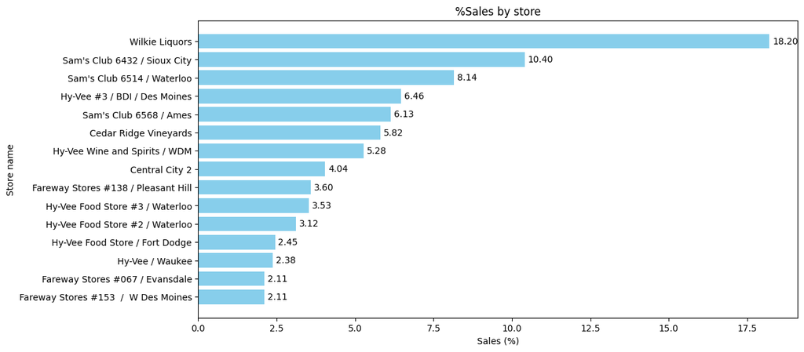

```python
# Create a horizontal bar plot using matplotlib
plt.figure(figsize=(12, 6))
bars=plt.barh(sales_percentage.head(15).index, sales_percentage.head(15), color='skyblue')
plt.xlabel('Sales (%)')
plt.ylabel('Store name')
plt.title('%Sales by store')
plt.gca().invert_yaxis()  # Invert the y-axis to show the highest percentage at the top

for bar in bars:
    plt.text(
        bar.get_width() + 0.1,  # Positioning the text next to the bar
        bar.get_y() + bar.get_height() / 2,  # Centering vertically
        f'{bar.get_width():.2f}',  # Format to one decimal place
        va='center',  # Vertical alignment
        ha='left'  # Horizontal alignment
    )

plt.show()
```

Now we replicate the plot using seaborn.

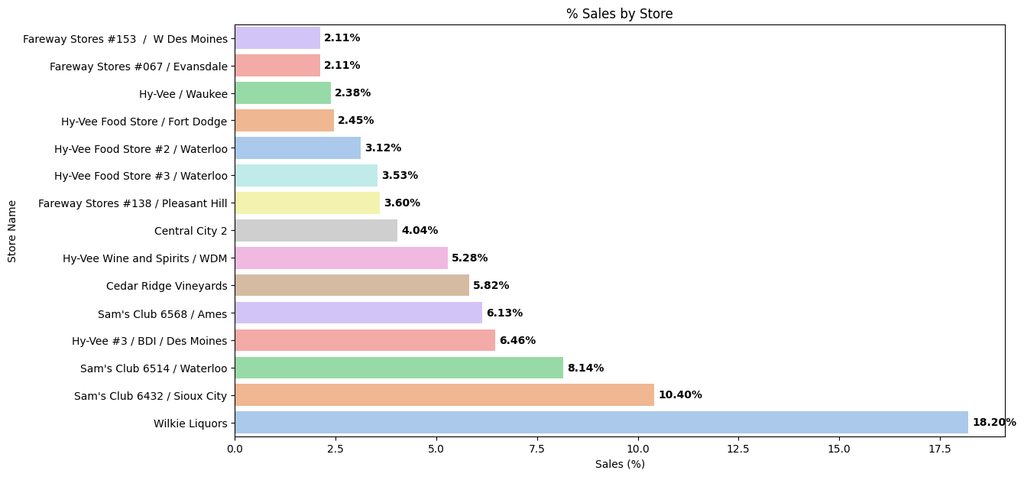

```python
# Convert to DataFrame for easier handling
sales_percentage_df = pd.Series(sales_percentage).reset_index()
sales_percentage_df.columns = ['Store Name', 'Sales Percentage']

# Create a horizontal bar plot using Seaborn
plt.figure(figsize=(13, 7))
sns.barplot(x='Sales Percentage', y='Store Name', data=sales_percentage_df.head(15), hue='Store Name', palette='pastel', legend=False)

plt.xlabel('Sales (%)')
plt.ylabel('Store Name')
plt.title('% Sales by Store')
plt.gca().invert_yaxis()  # Invert the y-axis to show the highest percentage at the top

# Display the values next to the bars
for index, row in sales_percentage_df.head(15).iterrows():
    plt.text(
        row['Sales Percentage'] + 0.1,  # Positioning the text next to the bar
        index,  # y position of the bar
        f'{row["Sales Percentage"]:.2f}%',  # Format to one decimal place
        va='center',  # Vertical alignment
        fontweight='bold'  # Make the text bold
    )

plt.show()
```

Finally, we plot the data using plotly.

```python
# Create a horizontal bar plot using Plotly
fig = px.bar(sales_percentage_df.head(15), x='Sales Percentage', y='Store Name', text='Sales Percentage', color='Sales Percentage', title='% Sales by Store')
fig.update_traces(texttemplate='%{text:.2f}%', textposition='outside')  # Format the text to two decimal places
fig.update_layout(xaxis_title='Sales (%)', yaxis_title='Store Name', yaxis_categoryorder='total ascending')  # Set the x and y-axis labels

# Set xlimit from 0 to 20
fig.update_xaxes(range=[0, 20])

# Change colour to gradient viridis by Sales Percentage
fig.update_traces(marker=dict(color=sales_percentage_df['Sales Percentage'], colorscale='viridis', showscale=True))

# Display the plot
fig.show(renderer = "browser")
```

### Summary of Results: Sales Percentage per Store

In this analysis, we computed the sales percentage per store based on the total sales in dollars. Here are the key findings:

- **Top Store by Sales Percentage**: Wilkie Liquors had the highest sales percentage, accounting for 18.20% of the total sales.
- **Top 5 Stores by Sales Percentage**:
  1. **Wilkie Liquors**: 18.20%
  2. **Sam's Club 6432 / Sioux City**: 10.40%
  3. **Sam's Club 6514 / Waterloo**: 8.14%
  4. **Hy-Vee #3 / BDI / Des Moines**: 6.46%
  5. **Sam's Club 6568 / Ames**: 6.13%
- **Distribution**: The sales percentages are heavily skewed, with a few stores contributing a significant portion of the total sales.
- **Visualization**: We used various visualization tools (matplotlib, seaborn, and plotly) to represent the data, providing both static and interactive views of the sales percentages per store.

These insights help in understanding the performance of different stores and can be useful for strategic decision-making and resource allocation.